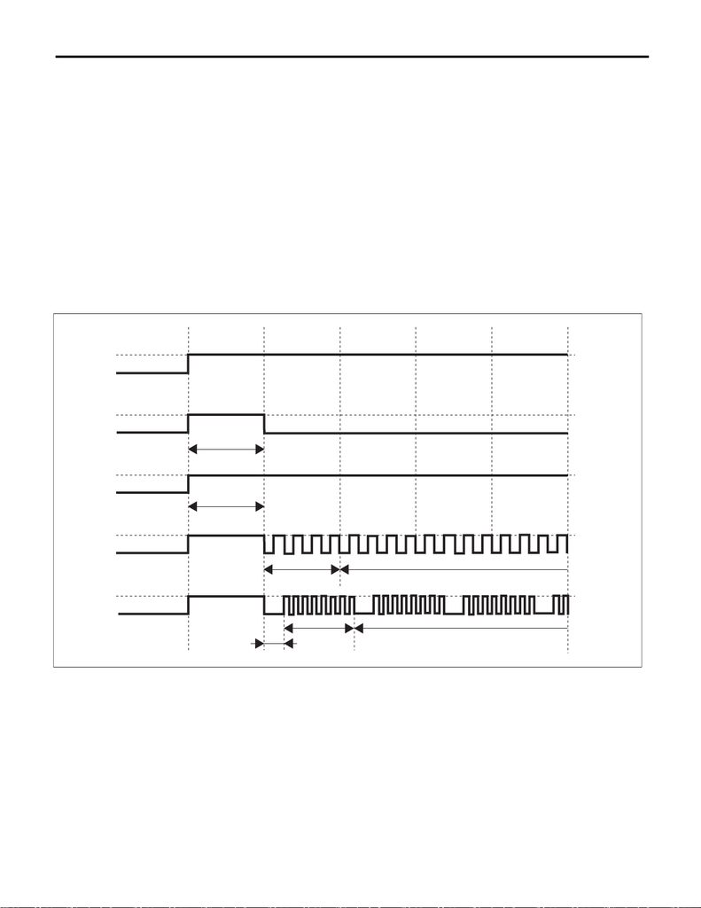

CVT(diag)-25

AT OIL TEMP Warning Light Display

CONTINUOUSLY VARIABLE TRANSMISSION (DIAGNOSTICS)

13.AT OIL TEMP Warning Light Display

A: OPERATION

The AT OIL TEMP light illuminates or blinks, when the ATF temperature is high and malfunction occurs in

CVT.

• At normal condition

After turning the ignition switch to ON, illuminates for 2 seconds then goes off.

• When ATF temperature is high

AT OIL TEMP light illuminates when the ATF temperature is abnormally high with the ignition switch ON.

• When malfunction is detected

AT OIL TEMP light blinks at 2 Hz when the TCM detects the malfunction of CVT with the ignition switch ON.

In this case, inspect using “Diagnostic Procedure with Diagnostic Trouble Code (DTC)”. <Ref. to CVT(diag)-

36, Diagnostic Procedure with Diagnostic Trouble Code (DTC).>

• When AT learning is not finished

AT OIL TEMP light repeats “Blinking at 4 Hz → Turning OFF” every two seconds, when the AT learning is not

completed with the ignition switch ON. In this case, perform the “Learning”. (During AT learning, the light

blinks at 2 Hz or illuminates.) <Ref. to CVT(diag)-23, Learning Control.>

If the AT OIL TEMP light does not illuminate, or illumination patterns are not as above, check the AT OIL

TEMP light circuit. <Ref. to CVT(diag)-26, INSPECTION, AT OIL TEMP Warning Light Display.>

(A) Ignition switch condition

(2) When ATF temperature is high

(2)

(3)

(4)

CVT00516

(1)

OFF

ON

(A)

OFF

OFF

OFF

OFF

Illuminate

0.5 sec.

Illuminate

2 sec.

Repeated

Illuminate

2 sec.

Repeated

2 sec.

2 sec.

Illuminate

[figure not shown]

CVT(diag)-26

AT OIL TEMP Warning Light Display

CONTINUOUSLY VARIABLE TRANSMISSION (DIAGNOSTICS)

B: INSPECTION

DIAGNOSIS:

• CAN communication is lost with the combination meter.

• Combination meter malfunction

• TCM is in special control mode.

• AT learning is not finished.

TROUBLE SYMPTOM:

• When the ignition switch is turned to ON, the AT OIL TEMP light does not illuminate.

• AT OIL TEMP light remains lit after engine start.

Step Check Yes No

1 CHECK DTC.

Read the DTC relating the TCM using the Sub-

aru Select Monitor.

Is DTC U0155 or U0423 dis-

played?

Perform the self-

diagnosis of com-

bination meter.

Go to step 2.

2 CHECK DTC.

Read the DTC relating the TCM using the Sub-

aru Select Monitor.

Are DTCs other than U0155

and U0423 displayed?

Perform the diag-

nosis according to

DTC.

Go to step 3.

3 CHECK COMBINATION METER.

Read DTC of combination meter.

Is DTC displayed? Perform the diag-

nosis according to

DTC.

Go to step 4.

4 CHECK AT OIL TEMP LIGHT.

Turn the ignition switch to ON.

Does AT OIL TEMP light illumi-

nate and then go off in 2 sec-

onds?

Go to step 5. Perform the self-

diagnosis of com-

bination meter.

<Ref. to IDI-6,

SELF-DIAGNO-

SIS DISPLAY

MODE, OPERA-

TION, Combina-

tion Meter

System.>

5 CHECK AT OIL TEMP LIGHT.

Start the engine.

Does the AT OIL TEMP light go

off?

Current condition

is normal. Go back

to Basic Diagnostic

Procedure. <Ref.

to CVT(diag)-2,

Basic Diagnostic

Procedure.>

Go to step 6.

6 CHECK DTC.

Read the DTC relating the TCM using the Sub-

aru Select Monitor.

Is DTC displayed? Perform the diag-

nosis according to

DTC.

Go to step 7.

7 CHECK TCM.

Read the data of «ATF Temperature Lamp»

using the Subaru Select Monitor.

Is “ON” displayed? Go to step 8. Perform the self-

diagnosis of com-

bination meter.

<Ref. to IDI-6,

SELF-DIAGNO-

SIS DISPLAY

MODE, OPERA-

TION, Combina-

tion Meter

System.>

8 CHECK TCM.

Read the data of «ATF Temp.» using the Sub-

aru Select Monitor.

Is the display 125°C or more? Go to step 9. Replace the TCM.

<Ref. to

CVT(TR690)-126,

Transmission Con-

trol Module

(TCM).>

[figure not shown]

CVT(diag)-27

AT OIL TEMP Warning Light Display

CONTINUOUSLY VARIABLE TRANSMISSION (DIAGNOSTICS)

9 CHECK ATF TEMPERATURE.

Check the real fluid temperature from the trans-

mission case surface temperature.

Does it clearly differ from the

«ATF Temp.» displayed on Sub-

aru Select Monitor?

Perform the diag-

nosis according to

DTC P0712. If

there is no prob-

lem, perform the

diagnosis accord-

ing to DTC P0713.

When ATF temper-

ature can be

judged as actually

high, perform the

diagnosis again

after the ATF tem-

perature lowers.